# Denver Marijuana Crime

This notebook will be used to examine information from the Marijuana Crime dataset provided by the Denver Open Data Catalog. Let’s take a look at the dataset and load necessary libraries.

```r
library(caret, quietly = TRUE)
data <- read.csv("crime_marijuana.csv")
head(data)
```

|  | INCIDENT_ID | FIRST_OCCURENCE_DATE | LAST_OCCURENCE_DATE | REPORTDATE | INCIDENT_ADDRESS | GEO_X | GEO_Y | DISTRICT_ID | PRECINCT_ID | OFFENSE_CODE | OFFENSE_TYPE_ID | OFFENSE_CATEGORY_ID | MJ_RELATION_TYPE | NEIGHBORHOOD_ID |
| --- | --- | --- | --- | --- | --- | --- | --- | --- | --- | --- | --- | --- | --- | --- |
| 1 | 2014679515 | 24-DEC-14 | 24-DEC-14 | 24-DEC-14 | 4105 N JASON ST | 3140597 | 1706917 | 1 | 112 | 2203 | BURGLARY - BUSINESS BY FORCE | Burglary | INDUSTRY\n | sunnyside |
| 2 | 2014498488 | 19-SEP-14 | 20-SEP-14 | 20-SEP-14 | 2424 E 43RD AVE | 3152489 | 1708074 | 2 | 212 | 2203 | BURGLARY - BUSINESS BY FORCE | Burglary | INDUSTRY\n | elyria-swansea |
| 3 | 201690330 | 12-FEB-16 | 12-FEB-16 | 12-FEB-16 | 2193 W EVANS AVE | 3137109 | 1672567 | 4 | 422 | 2203 | BURGLARY - BUSINESS BY FORCE | Burglary | INDUSTRY\n | college-view-south-platte |
| 4 | 2016403549 | 27-JUN-16 | 27-JUN-16 | 27-JUN-16 | 2420 S COLORADO BLVD | 3157568 | 1670426 | 3 | 314 | 2203 | BURGLARY - BUSINESS BY FORCE | Burglary | INDUSTRY\n | university-hills |
| 5 | 201318891 | 12-JAN-13 | 12-JAN-13 | 12-JAN-13 | 9700 E ILIFF AVE | 3176311 | 1670689 | 3 | 323 | 1205 | ROBBERY - STREET | Robbery-Street-Res | NON-INDUSTRY\n | hampden |
| 6 | 20122767 | 03-JAN-12 | 03-JAN-12 | 03-JAN-12 | 3900 E 48TH AVE | 3156932 | 1710798 | 2 | 212 | 2203 | BURGLARY - BUSINESS BY FORCE | Burglary | INDUSTRY\n | elyria-swansea |

Note that the data are divided into two main categories of crimes: industry and non-industry crimes. Industry crimes are those perpetrated by or against a business in the marijuana industry. Non-industry crimes do not have an obvious relation to the industry, but still involved marijuana. Let’s try to answer a simple question - Can the location of a crime, given by the x and y coordinates of the crime, be used to predict whether it was an industry-related crime or a non-industry-related crime? One would expect that industry crimes are more likely to be committed near marijuana businesses whereas non-industry crimes are less likely to be committed near marijuana businesses. This question may be a bit trivial, but it provides a simple project to learn a bit more about classification in R. First, let’s see how a majority-classifier would perform on this question.

```r
summary(data$MJ_RELATION_TYPE)
```

```
    INDUSTRY\n NON-INDUSTRY\n
          1039            415
```

Out of 1454 crimes, 1039 are industry-related, or 71%. In order to meaningfully answer the question, we want to outperform this accuracy.

Why only use the x and y coordinates as features, and not other columns? The other columns can introduce more overfitting (such as INCIDENT_ID) or have information that directly relates to the MJ_RELATION_TYPE (for example, most crimes where the OFFENSE_TYPE_ID is BURGLARY - BUSINESS BY FORCE are industry crimes). GEO_X and GEO_Y do not have an obvious relation to the MJ_RELATION_TYPE field.

Let’s start by plotting the crimes based on x, y, mj_relation_type.

```r
x <- data$GEO_X
y <- data$GEO_Y
class <- data$MJ_RELATION_TYPE
x_ind <- x[class == "INDUSTRY\n"]
y_ind <- y[class == "INDUSTRY\n"]
x_nind <- x[class == "NON-INDUSTRY\n"]
y_nind <- y[class == "NON-INDUSTRY\n"]
plot(x_nind,y_nind,col=rgb(red=1,green=0,blue=0, alpha=0.2), pch=16, xlab = "GEO_X", ylab = "GEO_Y")
points(x_ind,y_ind,col=rgb(red=0,green=0,blue=0, alpha=0.2), pch=16)
```

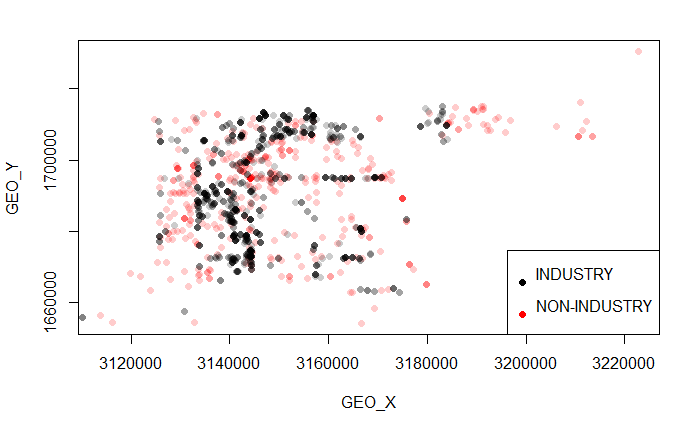

```r
legend("bottomright",NULL,unique(class),col=1:length(unique(class)),pch=16)
```

That looks promising! The industry crimes seem to be densely packed whereas the non-industry crimes seem to be more spread out. Next, we create a training/testing data split using caret.

```r
data_nona <- data[complete.cases(data),]
tindex <- createDataPartition(data_nona$MJ_RELATION_TYPE, p=0.8, list=FALSE)
data_train <- data_nona[tindex,]
x_train <- data_train[,c("GEO_X","GEO_Y")]
y_train <- data_train[,"MJ_RELATION_TYPE"]
data_test <- data_nona[-tindex,]
x_test <- data_test[,c("GEO_X","GEO_Y")]
y_test <- data_test[,"MJ_RELATION_TYPE"]
```

With the training and testing data split, the model can be created.

```r
mjFit <- train(x=x_train, y=y_train)
```

Finally we can test the model.

```r
pred <- predict(mjFit, x_test)
confusionMatrix(pred, y_test)
```

```
Confusion Matrix and Statistics

                Reference
Prediction       INDUSTRY\n NON-INDUSTRY\n
  INDUSTRY\n            197             18
  NON-INDUSTRY\n         10             65

               Accuracy : 0.9034
                 95% CI : (0.8635, 0.9349)
    No Information Rate : 0.7138
    P-Value [Acc > NIR] : 2.71e-15

                  Kappa : 0.7567
 Mcnemar's Test P-Value : 0.1859

            Sensitivity : 0.9517
            Specificity : 0.7831
         Pos Pred Value : 0.9163
         Neg Pred Value : 0.8667
             Prevalence : 0.7138
         Detection Rate : 0.6793
   Detection Prevalence : 0.7414
      Balanced Accuracy : 0.8674

       'Positive' Class : INDUSTRY\n
```

That turns out to be a decent result, indicating that there probably is a relation between crime location and MJ_RELATION_TYPE. We can answer our question affirmatively.